# exam_3.Rmd

Hamaad Mehal

4/19/2020

# 1A

I believe the correlation coefficient between the number of migrants and the amount of money that they send home will be strongly positive as remittances are known to increase with more migrants that are in the US. I would control variables such as legality (which might affect the ability to send money back) and economic downturns/unemployment rates which, as we are seeing during this COVID crisis, plays a disruptive, abnormal force in usual economic activities such as remittances.

# 1B

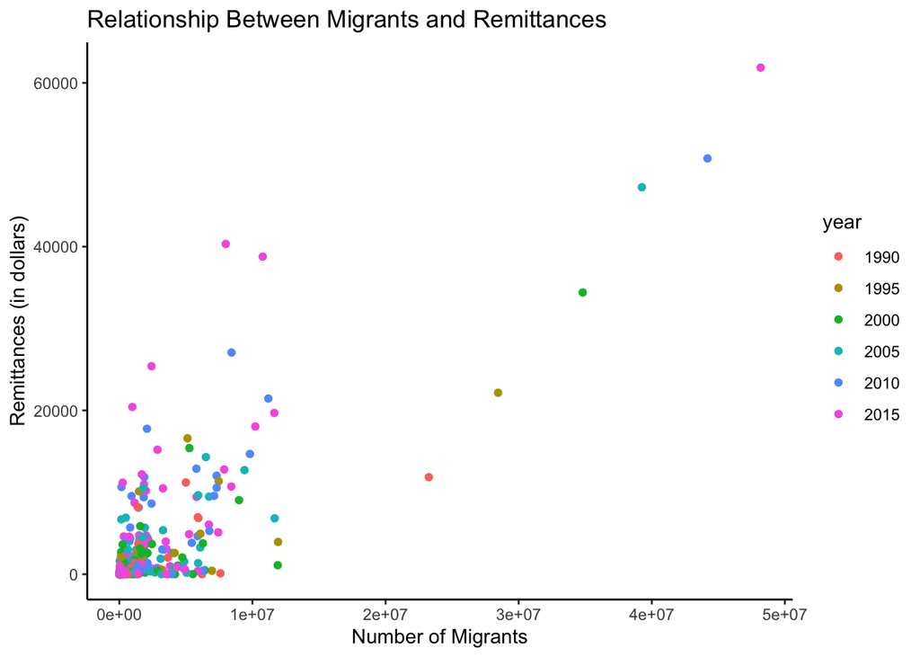

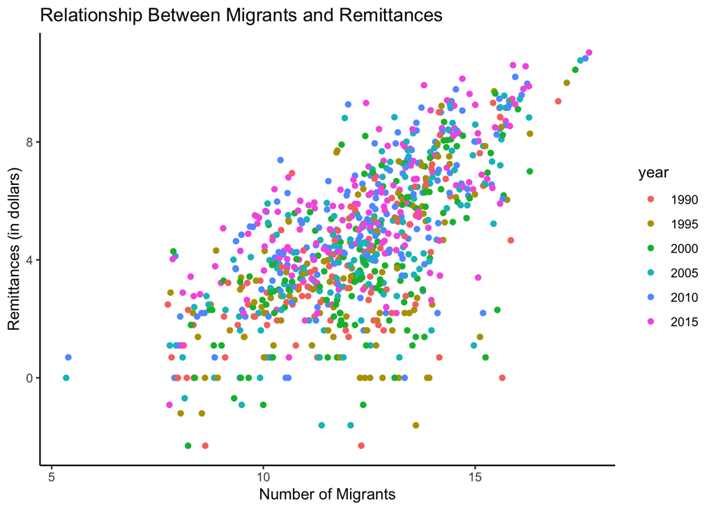

Table: Data summary

| Name | log_join |
| --- | --- |
| Number of rows | 841 |
| Number of columns | 7 |
| _______________________ |  |
| Column type frequency: |  |
| character | 2 |
| factor | 1 |
| numeric | 4 |
| ________________________ |  |
| Group variables | None |

**Variable type: character**

| skim_variable | n_missing | complete_rate | min | max | empty | n_unique | whitespace |
| --- | --- | --- | --- | --- | --- | --- | --- |
| country | 0 | 1 | 4 | 32 | 0 | 178 | 0 |
| year | 0 | 1 | 4 | 4 | 0 | 6 | 0 |

**Variable type: factor**

| skim_variable | n_missing | complete_rate | ordered | n_unique | top_counts |
| --- | --- | --- | --- | --- | --- |
| continent | 0 | 1 | FALSE | 5 | Afr: 248, Asi: 193, Eur: 191, Ame: 148 |

**Variable type: numeric**

| skim_variable | n_missing | complete_rate | mean | sd | p0 | p25 | p50 | p75 | p100 | hist |
| --- | --- | --- | --- | --- | --- | --- | --- | --- | --- | --- |
| value.migrants | 0 | 1 | 1174989.16 | 3569138.58 | 209.00 | 53034.00 | 241624.00 | 824492.00 | 48178877.00 | ▇▁▁▁▁ |
| value.remittances | 0 | 1 | 1484.68 | 4943.20 | 0.10 | 18.00 | 82.00 | 597.00 | 61859.00 | ▇▁▁▁▁ |
| log_migrants | 0 | 1 | 12.27 | 2.00 | 5.34 | 10.88 | 12.40 | 13.62 | 17.69 | ▁▃▇▆▂ |
| log_remittances | 0 | 1 | 4.61 | 2.53 | -2.30 | 2.89 | 4.41 | 6.39 | 11.03 | ▁▅▇▅▂ |

# 1C

| Year | Correlation |
| --- | --- |
| 1990 | 0.65 |
| 1995 | 0.57 |
| 2000 | 0.62 |
| 2005 | 0.70 |
| 2010 | 0.72 |
| 2015 | 0.73 |

# 2A

Effect of Number of Migrants on Amount of Remittances

| Both IV and DV are logged Variable | Both IV and DV are logged Estimate | Both IV and DV are logged Lower Bound | Both IV and DV are logged Upper Bound |
| --- | --- | --- | --- |
| (Intercept) | -5.63 | -6.44 | -4.83 |
| log_migrants | 0.84 | 0.77 | 0.90 |

# 2B

The regression tells us that remittances increase by 0.84% for every percent increase in migrants. The Bayesian interpretations states that we are 95% sure that true average treatment effect is between 0.77% and 0.90% whereas the frequentist interpration says that, for 95% of the times this data is sampled, the average treatment effect would be that remittances increase in the range of 0.77% and 0.90%.

# 2C

$$y = 17.69 * 0.84 - 5.63 = 9.23$$

```
## [1] 9.15
```

# 3A

Effect of Number of Migrants on Amount of Remittances

| Both IV and DV are logged Variable | Both IV and DV are logged Estimate | Both IV and DV are logged Lower Bound | Both IV and DV are logged Upper Bound |
| --- | --- | --- | --- |
| (Intercept) | -3.98 | -5.77 | -2.19 |
| log_migrants | 0.62 | 0.47 | 0.76 |
| continentAmericas | -2.45 | -4.89 | -0.02 |
| continentAsia | 1.03 | -1.62 | 3.68 |
| continentEurope | -2.57 | -5.29 | 0.14 |
| continentOceania | -0.06 | -2.59 | 2.46 |
| log_migrants:continentAmericas | 0.29 | 0.08 | 0.49 |
| log_migrants:continentAsia | 0.05 | -0.16 | 0.26 |
| log_migrants:continentEurope | 0.33 | 0.12 | 0.55 |
| log_migrants:continentOceania | 0.13 | -0.10 | 0.36 |

# 3B

# 4

| Year | Estimate | Lower Bound | Upper Bound |
| --- | --- | --- | --- |
| 1990 | 0.76 | 0.59 | 0.94 |
| 1995 | 0.76 | 0.56 | 0.96 |
| 2000 | 0.81 | 0.64 | 0.99 |
| 2005 | 0.87 | 0.73 | 1.02 |
| 2010 | 0.86 | 0.73 | 0.98 |
| 2015 | 0.80 | 0.68 | 0.92 |